# ARC Additions: Notebook of new functions and testing / benchmarking to verify parameters and sources

Goal: Transfer hyperfine atomic physics functions from internal Matlab toolbox to ARC.

JP, University of Strathclyde (2020)

```python
#Configure Environment

# NOTE: Uncomment following two lines ONLY if you are not using installation via pip
# import sys, os
# sys.path.insert(0,"..")  # add current directory in look up path for Python packages

from arc import *

%matplotlib inline
import matplotlib.pyplot as plt
import numpy as np

cs = Cesium()
rb87 = Rubidium87()
```

## Check ARC Parameters for D1/2 and inverted (n+1)P_{1/2,3/2}

- New function "[A,B] = self.getHFSCoefficients(self,n, l, j, s=None)" added to return HFS constants in Hz. Refernce [5] and [6] have useful reference info

### Hyperfine Structure Functions

- [A,B] = atm.getHFSCoefficients(n,l,j)

Returns HFS constants in Hz. This is currently using hard-coded values for Cs and Rb, but has been written as a place-holder for adding in a table. Refernce [5] and [6] have useful reference info.

- getHFSEnergyShift(j,f,A,B)

Returns HFS Energy shift from centre of mass.

\begin{equation} \Delta E_\mathrm{hfs} = \frac{A}{2}K+B\frac{\frac{3}{2}K(K+1)-2I(I+1)J(J+1)}{2I(2I-1)2J(2J-1)}, \end{equation}

where $K=F(F+1)-I(I+1)-J(J+1)$.

##### References

[1] Steck

[2] M. Ortiz and J. Campos, J. Quant. Spectrosc. Radiat. Transfer 26, 107 (1981)

[3] Vasilyev, A. A. and Savukov, I. M. and Safronova, M. S. and Berry, H. G., PRA 66, 020101 (2002)

[4] M. S. Safronova, Carl J. Williams, and Charles W. Clark, PRA 69, 022509 (2004)

[5] D. Feiertag, A. Sahm, and G. zu Putlitz, Z. Phys. 255, 93 (1972)

[6] E. Arrimondo, M. Inguscio and P. Violino, Rev. Mod. Phys. 49, 31 (1977)

```python
print("Cs Numbers")
print("==========")
print("State Lifetimes:")
#Lifetime Comparison -->
print("\t[1] : Tau6P1/2 = 34.894(44) ns, ARC = %2.3f ns (%2.2f %% error)" % (cs.getStateLifetime(6,1,0.5)*1e9,(cs.getStateLifetime(6,1,0.5)*1e9-34.894)/34.894*100))
print("\t[1] : Tau6P3/2 = 30.473(44) ns, ARC = %2.3f ns (%2.2f %% error)" % (cs.getStateLifetime(6,1,1.5)*1e9,(cs.getStateLifetime(6,1,1.5)*1e9-30.473)/30.473*100))
print("\t[2] : Tau7P1/2 = 155 ns, ARC = %2.3f ns (%2.2f %% error)" % (cs.getStateLifetime(7,1,0.5)*1e9,(cs.getStateLifetime(7,1,0.5)*1e9-155)/155*100))
print("\t[2] : Tau7P3/2 = 133 ns, ARC = %2.3f ns (%2.2f %% error)" % (cs.getStateLifetime(7,1,1.5)*1e9,(cs.getStateLifetime(7,1,1.5)*1e9-133)/133*100))
#Matrix Elements
print("Matrix Elements")
r = 4.5003;rm = cs.getReducedMatrixElementJ(6,0,0.5,6,1,0.5)
print("\t[1] : <6S1/2||er||6P1/2> = %1.4f, ARC = %2.4f ns (%2.2f %% error)" % (r,rm,(rm-r)/r*100))
r = 6.3338;rm = cs.getReducedMatrixElementJ(6,0,0.5,6,1,1.5)
print("\t[1] : <6S1/2||er||6P3/2> = %1.4f, ARC = %2.4f ns (%2.2f %% error)" % (r,rm,(rm-r)/r*100))
r = 0.2757;rm = cs.getReducedMatrixElementJ(6,0,0.5,7,1,0.5)
print("\t[3] : <6S1/2||er||7P1/2> = %1.4f, ARC = %2.4f ns (%2.2f %% error)" % (r,rm,(rm-r)/r*100))
r = 0.5856;rm = cs.getReducedMatrixElementJ(6,0,0.5,7,1,1.5)
print("\t[3] : <6S1/2||er||7P3/2> = %1.4f, ARC = %2.4f ns (%2.2f %% error)" % (r,rm,(rm-r)/r*100))
#Hyperfine Splitting Coefficients
print("Hyperfine Constants")
[A,B]=cs.getHFSCoefficients(6,0,0.5)
omegaQ = 4*A
print("\t[1] : 6S1/2 A = %1.4f MHz,B = %1.4f MHz" % (A*1e-6,B*1e-6))
[A,B]=cs.getHFSCoefficients(6,1,0.5)
print("\t[1] : 6P1/2 A = %1.4f MHz,B = %1.4f MHz" % (A*1e-6,B*1e-6))
[A,B]=cs.getHFSCoefficients(6,1,1.5)
print("\t[1] : 6P3/2 A = %1.4f MHz,B = %1.4f MHz" % (A*1e-6,B*1e-6))
[A,B]=cs.getHFSCoefficients(7,1,0.5)
print("\t[5] : 7P1/2 A = %1.4f MHz,B = %1.4f MHz" % (A*1e-6,B*1e-6))
[A,B]=cs.getHFSCoefficients(7,1,1.5)
print("\t[6] : 7P3/2 A = %1.4f MHz,B = %1.4f MHz" % (A*1e-6,B*1e-6))

print("\nVerify getHFSCoefficients(j,f,A,B) using Cs 6P3/2")
[A,B]=cs.getHFSCoefficients(6,1,1.5)
Ehfs=cs.getHFSEnergyShift(1.5,5,A,B)
print("\t[1] : 6P3/2 F=5: Ehfs = +263.81 MHz --> ARC Ehfs = %f MHz" % (Ehfs*1e-6))
Ehfs=cs.getHFSEnergyShift(1.5,4,A,B)
print("\t[1] : 6P3/2 F=4: Ehfs =  +12.815 MHz --> ARC Ehfs = %f MHz" % (Ehfs*1e-6))
Ehfs=cs.getHFSEnergyShift(1.5,3,A,B)
print("\t[1] : 6P3/2 F=3: Ehfs = -188.44 MHz --> ARC Ehfs = %f MHz" % (Ehfs*1e-6))
Ehfs=cs.getHFSEnergyShift(1.5,2,A,B)
print("\t[1] : 6P3/2 F=2: Ehfs = -339.64 MHz --> ARC Ehfs = %f MHz" % (Ehfs*1e-6))


#Clock Frequency
print("\n\t[1] : 6S1/2 Clock Frequency = 9.192631770 GHz --> ARC = %f GHz (%2.2f %% error)" % (omegaQ*1e-9,(omegaQ-9.192631770e9)/9.192631770e9*100))

print("\nRb Numbers")
print("==========")
print("State Lifetimes:")
#Lifetime Comparison -->
print("\t[1] : Tau5P1/2 = 27.70(4) ns, ARC = %2.3f ns (%2.2f %% error)" % (rb87.getStateLifetime(5,1,0.5)*1e9,(rb87.getStateLifetime(5,1,0.5)*1e9-27.70)/27.70*100))
print("\t[1] : Tau5P3/2 = 26.24(4) ns, ARC = %2.3f ns (%2.2f %% error)" % (rb87.getStateLifetime(5,1,1.5)*1e9,(rb87.getStateLifetime(5,1,1.5)*1e9-26.24)/26.24*100))
print("\t[4] : Tau6P1/2 = 125 ns, ARC = %2.3f ns (%2.2f %% error)" % (rb87.getStateLifetime(6,1,0.5)*1e9,(rb87.getStateLifetime(6,1,0.5)*1e9-125)/125*100))
print("\t[4] : Tau6P3/2 = 112 ns, ARC = %2.3f ns (%2.2f %% error)" % (rb87.getStateLifetime(6,1,1.5)*1e9,(rb87.getStateLifetime(6,1,1.5)*1e9-112)/112*100))
#Matrix Elements
print("Matrix Elements")
r = 4.2313;rm = rb87.getReducedMatrixElementJ(5,0,0.5,5,1,0.5)
print("\t[4] : <5S1/2||er||5P1/2> = %1.4f, ARC = %2.4f ns (%2.2f %% error)" % (r,rm,(rm-r)/r*100))
r = 5.9780;rm = rb87.getReducedMatrixElementJ(5,0,0.5,5,1,1.5)
print("\t[4] : <5S1/2||er||5P3/2> = %1.4f, ARC = %2.4f ns (%2.2f %% error)" % (r,rm,(rm-r)/r*100))
r = 0.333;rm = rb87.getReducedMatrixElementJ(5,0,0.5,6,1,0.5)
print("\t[4] : <5S1/2||er||6P1/2> = %1.4f, ARC = %2.4f ns (%2.2f %% error)" % (r,rm,(rm-r)/r*100))
r = 0.541;rm = rb87.getReducedMatrixElementJ(5,0,0.5,6,1,1.5)
print("\t[4] : <5S1/2||er||6P3/2> = %1.4f, ARC = %2.4f ns (%2.2f %% error)" % (r,rm,(rm-r)/r*100))
print("Hyperfine Constants")
[A,B]=rb87.getHFSCoefficients(5,0,0.5)
omegaQ = (0.5+rb87.I)*A
print("\t[1] : 5S1/2 A = %1.4f MHz,B = %1.4f MHz" % (A*1e-6,B*1e-6))
[A,B]=rb87.getHFSCoefficients(5,1,0.5)
print("\t[1] : 5P1/2 A = %1.4f MHz,B = %1.4f MHz" % (A*1e-6,B*1e-6))
[A,B]=rb87.getHFSCoefficients(5,1,1.5)
print("\t[1] : 5P3/2 A = %1.4f MHz,B = %1.4f MHz" % (A*1e-6,B*1e-6))
[A,B]=rb87.getHFSCoefficients(6,1,0.5)
print("\t[5] : 6P1/2 A = %1.4f MHz,B = %1.4f MHz" % (A*1e-6,B*1e-6))
[A,B]=rb87.getHFSCoefficients(6,1,1.5)
print("\t[6] : 6P3/2 A = %1.4f MHz,B = %1.4f MHz" % (A*1e-6,B*1e-6))

#Clock Frequency
print("\n\t[1] : 5S1/2 Clock Frequency =  6.83468261090429 GHz --> ARC = %f GHz (%2.2f %% error)" % (omegaQ*1e-9,(omegaQ-6.83468261090429e9)/6.83468261090429e9*100))
```

```
Cs Numbers
==========
State Lifetimes:
	[1] : Tau6P1/2 = 34.894(44) ns, ARC = 34.894 ns (0.00 % error)
	[1] : Tau6P3/2 = 30.473(44) ns, ARC = 30.474 ns (0.00 % error)
	[2] : Tau7P1/2 = 155 ns, ARC = 154.368 ns (-0.41 % error)
	[2] : Tau7P3/2 = 133 ns, ARC = 129.775 ns (-2.42 % error)
Matrix Elements
	[1] : <6S1/2||er||6P1/2> = 4.5003, ARC = 4.5003 ns (0.00 % error)
	[1] : <6S1/2||er||6P3/2> = 6.3338, ARC = 6.3337 ns (-0.00 % error)
	[3] : <6S1/2||er||7P1/2> = 0.2757, ARC = 0.2757 ns (0.00 % error)
	[3] : <6S1/2||er||7P3/2> = 0.5856, ARC = 0.5856 ns (0.00 % error)
Hyperfine Constants
	[1] : 6S1/2 A = 2298.1579 MHz,B = 0.0000 MHz
	[1] : 6P1/2 A = 291.9201 MHz,B = 0.0000 MHz
	[1] : 6P3/2 A = 50.2750 MHz,B = -0.5300 MHz
	[5] : 7P1/2 A = 94.3500 MHz,B = 0.0000 MHz
	[6] : 7P3/2 A = 16.6050 MHz,B = -0.1500 MHz

Verify getHFSCoefficients(j,f,A,B) using Cs 6P3/2
	[1] : 6P3/2 F=5: Ehfs = +263.81 MHz --> ARC Ehfs = 263.811250 MHz
	[1] : 6P3/2 F=4: Ehfs =  +12.815 MHz --> ARC Ehfs = 12.814821 MHz
	[1] : 6P3/2 F=3: Ehfs = -188.44 MHz --> ARC Ehfs = -188.436607 MHz
	[1] : 6P3/2 F=2: Ehfs = -339.64 MHz --> ARC Ehfs = -339.640179 MHz

	[1] : 6S1/2 Clock Frequency = 9.192631770 GHz --> ARC = 9.192632 GHz (0.00 % error)

Rb Numbers
==========
State Lifetimes:
	[1] : Tau5P1/2 = 27.70(4) ns, ARC = 27.690 ns (-0.04 % error)
	[1] : Tau5P3/2 = 26.24(4) ns, ARC = 26.238 ns (-0.01 % error)
	[4] : Tau6P1/2 = 125 ns, ARC = 129.295 ns (3.44 % error)
	[4] : Tau6P3/2 = 112 ns, ARC = 118.143 ns (5.48 % error)
Matrix Elements
	[4] : <5S1/2||er||5P1/2> = 4.2313, ARC = 4.2321 ns (0.02 % error)
	[4] : <5S1/2||er||5P3/2> = 5.9780, ARC = 5.9783 ns (0.01 % error)
	[4] : <5S1/2||er||6P1/2> = 0.3330, ARC = 0.3330 ns (0.00 % error)
	[4] : <5S1/2||er||6P3/2> = 0.5410, ARC = 0.5410 ns (0.00 % error)
Hyperfine Constants
	[1] : 5S1/2 A = 3417.3413 MHz,B = 0.0000 MHz
	[1] : 5P1/2 A = 408.3280 MHz,B = 0.0000 MHz
	[1] : 5P3/2 A = 84.7185 MHz,B = 12.4965 MHz
	[5] : 6P1/2 A = 132.5600 MHz,B = 0.0000 MHz
	[6] : 6P3/2 A = 27.6740 MHz,B = 3.9450 MHz

	[1] : 5S1/2 Clock Frequency =  6.83468261090429 GHz --> ARC = 6.834683 GHz (-0.00 % error)
```

### Angular Momentum Functions

- getSphericalDipoleMatrixElement(j1,mj1,j2,mj2,q)

  Angular part of spherical matrix element $A$ in units of reduced matrix element $\langle j\vert\vert\mu\vert\vert j'\rangle$ (Wigner-Eckart decomposition)

\begin{equation} \langle j m_j\vert \mu_q \vert j' m_j' \rangle = (-1)^{j-m_j}\begin{pmatrix}j&1&j'\\-m_j&-q&m_j'\end{pmatrix}\langle j\vert\vert\mu\vert\vert j'\rangle = A\langle j\vert\vert\mu\vert\vert j'\rangle, \end{equation}

- _reducedMatrixElementFJ(j1,f1,j2,f2)

  Reduced dipole matrix element $\langle f \vert\vert\mu\vert\vert f'\rangle$ in units of $\langle j\vert\vert\mu\vert\vert j'\rangle$

  \begin{equation} \langle f \vert\vert\mu\vert\vert f'\rangle = (-1)^{j+I+f'+1}\sqrt{(2f+1)(2f'+1)} \begin{Bmatrix}f&1&f'\\j'&I&j\end{Bmatrix}\langle j\vert\vert\mu\vert\vert j'\rangle, \label{eq:frf} \end{equation}
- getSphericalMatrixElementHFStoFS(j1,f1,mf1,j2,mj2,q)

  Angular coefficient of matrix element $\langle jfm_f \vert er_q\vert j'f'm_f'\rangle$ for coupling to state without resolved HFS, in units of $\langle j\vert\vert\mu\vert\vert j'\rangle$

\begin{align} \langle f,m_f \vert\mu_q\vert j',m_j'\rangle &=\displaystyle\sum_{f'}C_{j'm_j'I(m_f+q-m_j')}^{f'(m_f+q)}(-1)^{f-m_f}\begin{pmatrix}f&1&f'\\-m_f&-q&m_f+q\end{pmatrix}\\& \times(-1)^{j+I+f'+1}\sqrt{(2f+1)(2f'+1)} \begin{Bmatrix}f&1&f'\\j'&I&j\end{Bmatrix}\langle j\vert\vert\mu\vert\vert j'\rangle \end{align}

- getMagneticDipoleMatrixElementHFS(l,j,f1,mf1,m2,mf2,q)

Returns spherical component of magnetic dipole transition from $\vert f_1,m_{f_1}\rangle\rightarrow\vert f_2,m_{f_2}\rangle$ in units of $\mu_B B_q$ corresponding to relative strength of microwave transitions between hyperfine states of the same $n\ell j$ state driven by magnetic field with polarisation $q$.

\begin{align} \langle f_1,m_{f_1}\vert \mu_q \vert f_2,m_{f_2}\rangle = g_J \mu_B B_q (-1)^{f_2+j+I+1+f_1-m_{f_1}}\sqrt{(2f_1+1)(2f_2+1)j(j+1)(2j+1)} \begin{pmatrix}f_1&1&f_2\\-m_{f_1} & -q & m_{f_2}\end{pmatrix}\begin{Bmatrix}f_1&1&f_2\\j & I & j\end{Bmatrix} \end{align}

- getDipoleMatrixElementHFStoFS(n1,l1,j1,f1,mf1,n2,l2,j2,mj2,q)

  Full dipole matrix element $\langle jfm_f \vert er_q\vert j'f'm_f'\rangle$ for coupling to state without resolved HFS, in units of $ea_0$

\begin{align} \langle f,m_f \vert\mu_q\vert j',m_j'\rangle &=\displaystyle\sum_{f'}C_{j'm_j'I(m_f+q-m_j')}^{f'(m_f+q)}(-1)^{f-m_f}\begin{pmatrix}f&1&f'\\-m_f&-q&m_f+q\end{pmatrix}\\& \times(-1)^{j+I+f'+1}\sqrt{(2f+1)(2f'+1)} \begin{Bmatrix}f&1&f'\\j'&I&j\end{Bmatrix}\langle j\vert\vert\mu\vert\vert j'\rangle \end{align}

- getBranchingRatio(jg,fg,mfg,je,fe,mfe)

  Branching ratio $b$ for fraction of spontaneous decay from $\vert{j_e,f_e,m_{f_e}}\rangle\rightarrow\vert{j_g,f_g,m_{f_g}}\rangle$.

\begin{align} b = \displaystyle\sum_q (2j_e+1)\left(\begin{matrix}f_g & 1 & f_e \\ -m_{f_g} & q & m_{f_e}\end{matrix}\right)^2 \vert \langle j_e,f_e\vert \vert er \vert\vert j_g,f_g\rangle\vert^2 \end{align}

- getSaturationIntensity(ng,lg,jg,fg,mfg,ne,fe,je,fe,mfe)

  Returns saturation intenstiy $I_\mathrm{sat}$ for transition from $\vert{j_g,f_g,m_{f_g}}\rangle\rightarrow\vert{j_e,f_e,m_{f_e}}\rangle$ in units of W/m$^2$.

\begin{align} I_\mathrm{sat} = \frac{c\epsilon_0\Gamma^2\hbar^2}{4\vert \epsilon_q\cdot\mathrm{d}\vert^2} \end{align}

- getSaturationIntensityIsotropic(ng,lg,jg,fg,ne,fe,je,fe)

  Returns saturation intenstiy $I_\mathrm{sat}$ averaged over transiton from $f_g\rightarrow f_e$ for isotropic polarisation in units of W/m$^2$.

\begin{align} I_\mathrm{sat,iso} = \frac{c\epsilon_0\Gamma^2\hbar^2}{4\vert \mathrm{d_{iso}}\vert^2}, \end{align}

where $\vert \mathrm{d_{iso}}\vert^2$ is the isotropic dipole moment obtained by averaging over all possible transitions and polarisations. \begin{align} \vert d_{iso} \vert^2 = \frac{1}{3(2fg+1)}\displaystyle\sum_{q,m_{f_g}}\vert\langle ng,lg,jg,fg,mfg|er|ne,le,je,fe,mfg+q\rangle\vert^2 \end{align}

```python
#Test sph=atm.getSphericalDipoleMatrixElement(j1,mj1,j2,mj2,q)
#============================================================
print("\nTest sph=atm.getSphericalDipoleMatrixElement(j1,mj1,j2,mj2,q):")
print("==============================================================")
print("Spherical matrix element in units of reduced matrix element <j'||er||j> for j and  <f'||er||f> for f")
sph = cs.getSphericalDipoleMatrixElement(0.5,0.5,1.5,1.5,1)
print("|1/2,1/2> to |3/2,3/2> for q=1 (sigma+) : sph = 1/2 = %2.5f, sph = %2.5f" %(1/2,sph))
sph = cs.getSphericalDipoleMatrixElement(4,4,5,5,1)
print("|4,4> to |5,5> for q=1 (sigma+) : sph = sqrt{1/11} = %2.5f, sph = %2.5f" %(np.sqrt(1/11),sph))
sph = cs.getSphericalDipoleMatrixElement(4,4,4,4,0)
print("|4,4> to |4,4> for q=0 (pi) : sph = sqrt{4/45} = %2.5f, sph = %2.5f" %(np.sqrt(4/45),sph))
sph = cs.getSphericalDipoleMatrixElement(4,4,3,3,-1)
print("|4,4> to |3,3> for q=-1 (sigma-) : sph = 1/3 = %2.5f, sph = %2.5f" %(1/3,sph))

#Test sph=atm.getSphericalMatrixElementHFStoFS(j1,f1,mf1,j2,mj2,q)
#=================================================================
print("\nTest sph=atm.getSphericalMatrixElementHFStoFS(j1,f1,mf1,j2,mj2,q):")
print("==================================================================")
print("Spherical matrix element in units of reduced matrix element <j'||er||j'>")
sph = cs.getSphericalMatrixElementHFStoFS(1.5,5,5,0.5,0.5,-1)
print("Cs P3/2 |5,5> to S1/2 |1/2,1/2> for q=-1 (sigma-) : sph = 1/2 = %2.5f, sph = %2.5f" %(1/2,sph))
sph = cs.getSphericalMatrixElementHFStoFS(1.5,5,1,0.5,0.5,1)
print("Cs P3/2 |5,1> to S1/2 |1/2,1/2> for q=1 (sigma+) : sph = sqrt(1/40) = %2.5f, sph = %2.5f" %(np.sqrt(1/40),sph))
sph = cs.getSphericalMatrixElementHFStoFS(1.5,5,1,0.5,0.5,0)
print("Cs P3/2 |5,1> to S1/2 |1/2,1/2> for q=0 (pi) : sph = sqrt(1/12) = %2.5f, sph = %2.5f" %(np.sqrt(1/12),sph))
sph = cs.getSphericalMatrixElementHFStoFS(1.5,5,1,0.5,0.5,-1)
print("Cs P3/2 |5,1> to S1/2 |1/2,1/2> for q=-1 (sigma-) : sph = sqrt(1/24) = %2.5f, sph = %2.5f" %(np.sqrt(1/24),sph))

#Test sph=atm.getDipoleMatrixElementHFStoFS(j1,f1,mf1,j2,mj2,q)
#==============================================================
print("\nTest rme=atm.getDipoleMatrixElementHFStoFS(n1,l1,j1,f1,mf1,n2,l2,j2,mj2,q):")
print("=============================================================================")
print("Spherical matrix element in ea0")
rmeJ = cs.getReducedMatrixElementJ(6,1,1.5,80,0,0.5)
print("Cs <6P3/2||er||80S1/2> = 0.0086 = %f" %(rmeJ))
rme = cs.getDipoleMatrixElementHFStoFS(6,1,1.5,5,5,80,0,0.5,0.5,-1)
print("Cs 6P3/2 |5,5> to 80S1/2 |1/2,1/2> for q=-1 (sigma-) : 0.0043 ea0, rme = %f ea0" %(rme))
rme = cs.getDipoleMatrixElementHFStoFS(6,1,1.5,5,1,80,0,0.5,0.5,-1)
print("Cs 6P3/2 |5,1> to 80S1/2 |1/2,1/2> for q=-1 (sigma-) : 0.0018 ea0, rme = %f ea0" %(rme))

rmeJ = cs.getReducedMatrixElementJ(6,1,1.5,80,2,2.5)
print("Cs <6P3/2||er||80D5/2> = -0.0259 = %f" %(rmeJ))
rme = cs.getDipoleMatrixElementHFStoFS(6,1,1.5,5,5,80,2,2.5,2.5,1)
print("Cs 6P3/2 |5,5> to 80D5/2 |5/2,5/2> for q=+1 (sigma+) : -0.0106 ea0, rme = %f ea0" %(rme))

sph = cs.getSphericalMatrixElementHFStoFS(1.5,5,5,2.5,2.5,1)
print("Cs P3/2 |5,5> to D5/2 |5/2,5/2> for q=+1 (sigma+) : sph = sqrt(1/6) = %2.5f, sph = %2.5f" %(np.sqrt(1/6),sph))


#Test sph=atm.getMagneticDipoleMatrixElementHFS(l,j,f1,mf1,f2,mf2,q)
#==================================================================
print("\nTest sphB=atm.getMagneticDipoleMatrixElementHFS(l,j,f1,mf1,f2,mf2,q):")
print("=====================================================================")
print("Spherical matrix element in uB*B")
sphB = cs.getMagneticDipoleMatrixElementHFS(0,0.5,4,0,3,0,0)
print("Cs 6S1/2 <4,0|B_0|3,0> = 1.000 = %f muB" %(sphB))
sphB = cs.getMagneticDipoleMatrixElementHFS(0,0.5,4,3,3,3,0)
print("Cs 6S1/2 <4,3|B_0|3,3> = sqrt(7/16) = %f = %f muB" %(np.sqrt(7/16),sphB))
sphB = cs.getMagneticDipoleMatrixElementHFS(0,0.5,4,4,3,3,-1)
print("Cs 6S1/2 <4,4|B_1|3,3> = sqrt(7/4) = %f = %f muB" %(np.sqrt(7/4),sphB))
sphB = rb87.getMagneticDipoleMatrixElementHFS(0,0.5,2,0,1,0,0)
print("Rb 5S1/2 <2,0|B_0|1,0> = 1.000 = %f muB" %(sphB))
sphB = rb87.getMagneticDipoleMatrixElementHFS(0,0.5,2,1,1,1,0)
print("Rb 5S1/2 <2,1|B_0|1,1> = sqrt(3/4) = %f = %f muB" %(np.sqrt(3/4),sphB))
sphB = rb87.getMagneticDipoleMatrixElementHFS(0,0.5,2,2,1,1,-1)
print("Rb 5S1/2 <2,2|B_1|1,1> = sqrt(3/2) = %f = %f muB" %(np.sqrt(3/2),sphB))

#Test getBranchingRatio(jg,fg,mfg,je,fe,mfe)
#===========================================
print("\nTest br=atm.getBranchingRatio(jg,fg,mfg,je,fe,mfe):")
print("===================================================")
#Cs P3/2 |5,5> to S1/2|4,4> = 1
br = cs.getBranchingRatio(0.5,4,4,1.5,5,5)
print("Cs P3/2 |5,5> to S1/2|4,4> = 1, br = %2.5f" %(br))
#Cs P3/2 |5,4> to S1/2|4,4> = 1/5
br = cs.getBranchingRatio(0.5,4,4,1.5,5,4)
print("Cs P3/2 |5,4> to S1/2|4,4> = 1/5 = %2.5f, br = %2.5f" %(1/5,br))
#Cs P3/2 |5,4> to S1/2|4,3> = 4/5
br = cs.getBranchingRatio(0.5,4,3,1.5,5,4)
print("Cs P3/2 |5,4> to S1/2|4,3> = 4/5 = %2.5f, br = %2.5f" %(4/5,br))
#Cs P3/2 |4,4> to S1/2|4,4> = 7/15
br = cs.getBranchingRatio(0.5,4,4,1.5,4,4)
print("Cs P3/2 |4,4> to S1/2|4,4> = 7/15 = %2.5f, br = %2.5f" %(7/15,br))
#Cs P3/2 |4,4> to S1/2|4,3> = 7/60
br = cs.getBranchingRatio(0.5,4,3,1.5,4,4)
print("Cs P3/2 |4,4> to S1/2|4,3> = 7/60 = %2.5f, br = %2.5f" %(7/60,br))
#Cs P3/2 |4,4> to S1/2|3,3> = 7/60
br = cs.getBranchingRatio(0.5,3,3,1.5,4,4)
print("Cs P3/2 |4,4> to S1/2|3,3> = 5/12 = %2.5f, br = %2.5f" %(5/12,br))


#Test getSaturationIntensity(ng,lg,jg,fg,mfg,ne,le,je,fe,mfe)
#============================================================
print("\nTest Is=atm.getSaturationIntensity(ng,lg,jg,fg,mfg,ne,le,je,fe,mfe):")
print("====================================================================")
#Cs P3/2 |5,5> to S1/2|4,4> = 11 W/m^2
Is = cs.getSaturationIntensity(6,0,0.5,4,4,6,1,1.5,5,5)
print("Cs 6S1/2|4,4> to 6P3/2 |5,5> Is = 11 W/m^2, br = %2.5f W/m^2" %(Is))
Is = cs.getSaturationIntensity(6,0,0.5,4,0,6,1,1.5,5,0)
print("Cs 6S1/2|4,0> to 6P3/2 |5,0> Is = 19.8 W/m^2, br = %2.5f W/m^2" %(Is))

#Test getSaturationIntensityIsotropic(ng,lg,jg,fg,ne,le,je,fe)
#============================================================
print("\nTest Is=atm.getSaturationIntensityIsotropic(ng,lg,jg,fg,ne,le,je,fe):")
print("======================================================================")
#Cs P3/2 |5,5> to S1/2|4,4> = 11 W/m^2
Is = cs.getSaturationIntensityIsotropic(6,0,0.5,4,6,1,1.5,5)
print("Cs 6S1/2 F=4 to 6P3/2 F=5 Is_ISO = 27.059 W/m^2 [1], Is_ISO = %2.5f W/m^2" %(Is))
Is = cs.getSaturationIntensityIsotropic(6,0,0.5,4,6,1,1.5,4)
print("Cs 6S1/2 F=4 to 6P3/2 F=4 Is_ISO = 56.69 W/m^2, Is_ISO = %2.5f W/m^2" %(Is))
```

```
Test sph=atm.getSphericalDipoleMatrixElement(j1,mj1,j2,mj2,q):
==============================================================
Spherical matrix element in units of reduced matrix element <j'||er||j> for j and  <f'||er||f> for f
|1/2,1/2> to |3/2,3/2> for q=1 (sigma+) : sph = 1/2 = 0.50000, sph = 0.50000
|4,4> to |5,5> for q=1 (sigma+) : sph = sqrt{1/11} = 0.30151, sph = 0.30151
|4,4> to |4,4> for q=0 (pi) : sph = sqrt{4/45} = 0.29814, sph = 0.29814
|4,4> to |3,3> for q=-1 (sigma-) : sph = 1/3 = 0.33333, sph = 0.33333

Test sph=atm.getSphericalMatrixElementHFStoFS(j1,f1,mf1,j2,mj2,q):
==================================================================
Spherical matrix element in units of reduced matrix element <j'||er||j'>
Cs P3/2 |5,5> to S1/2 |1/2,1/2> for q=-1 (sigma-) : sph = 1/2 = 0.50000, sph = 0.50000
Cs P3/2 |5,1> to S1/2 |1/2,1/2> for q=1 (sigma+) : sph = sqrt(1/40) = 0.15811, sph = 0.15811
Cs P3/2 |5,1> to S1/2 |1/2,1/2> for q=0 (pi) : sph = sqrt(1/12) = 0.28868, sph = 0.28868
Cs P3/2 |5,1> to S1/2 |1/2,1/2> for q=-1 (sigma-) : sph = sqrt(1/24) = 0.20412, sph = 0.20412

Test rme=atm.getDipoleMatrixElementHFStoFS(n1,l1,j1,f1,mf1,n2,l2,j2,mj2,q):
=============================================================================
Spherical matrix element in ea0
Cs <6P3/2||er||80S1/2> = 0.0086 = -0.008715
Cs 6P3/2 |5,5> to 80S1/2 |1/2,1/2> for q=-1 (sigma-) : 0.0043 ea0, rme = -0.004358 ea0
Cs 6P3/2 |5,1> to 80S1/2 |1/2,1/2> for q=-1 (sigma-) : 0.0018 ea0, rme = -0.001779 ea0
Cs <6P3/2||er||80D5/2> = -0.0259 = -0.025645
Cs 6P3/2 |5,5> to 80D5/2 |5/2,5/2> for q=+1 (sigma+) : -0.0106 ea0, rme = -0.010469 ea0
Cs P3/2 |5,5> to D5/2 |5/2,5/2> for q=+1 (sigma+) : sph = sqrt(1/6) = 0.40825, sph = 0.40825

Test sphB=atm.getMagneticDipoleMatrixElementHFS(l,j,f1,mf1,f2,mf2,q):
=====================================================================
Spherical matrix element in uB*B
Cs 6S1/2 <4,0|B_0|3,0> = 1.000 = 1.000000 muB
Cs 6S1/2 <4,3|B_0|3,3> = sqrt(7/16) = 0.661438 = 0.661438 muB
Cs 6S1/2 <4,4|B_1|3,3> = sqrt(7/4) = 1.322876 = 1.322876 muB
Rb 5S1/2 <2,0|B_0|1,0> = 1.000 = 1.000000 muB
Rb 5S1/2 <2,1|B_0|1,1> = sqrt(3/4) = 0.866025 = 0.866025 muB
Rb 5S1/2 <2,2|B_1|1,1> = sqrt(3/2) = 1.224745 = 1.224745 muB

Test br=atm.getBranchingRatio(jg,fg,mfg,je,fe,mfe):
===================================================
Cs P3/2 |5,5> to S1/2|4,4> = 1, br = 1.00000
Cs P3/2 |5,4> to S1/2|4,4> = 1/5 = 0.20000, br = 0.20000
Cs P3/2 |5,4> to S1/2|4,3> = 4/5 = 0.80000, br = 0.80000
Cs P3/2 |4,4> to S1/2|4,4> = 7/15 = 0.46667, br = 0.46667
Cs P3/2 |4,4> to S1/2|4,3> = 7/60 = 0.11667, br = 0.11667
Cs P3/2 |4,4> to S1/2|3,3> = 5/12 = 0.41667, br = 0.41667

Test Is=atm.getSaturationIntensity(ng,lg,jg,fg,mfg,ne,le,je,fe,mfe):
====================================================================
Cs 6S1/2|4,4> to 6P3/2 |5,5> Is = 11 W/m^2, br = 11.02370 W/m^2
Cs 6S1/2|4,0> to 6P3/2 |5,0> Is = 19.8 W/m^2, br = 19.84266 W/m^2

Test Is=atm.getSaturationIntensityIsotropic(ng,lg,jg,fg,ne,le,je,fe):
======================================================================
Cs 6S1/2 F=4 to 6P3/2 F=5 Is_ISO = 27.059 W/m^2 [1], Is_ISO = 27.05817 W/m^2
Cs 6S1/2 F=4 to 6P3/2 F=4 Is_ISO = 56.69 W/m^2, Is_ISO = 56.69332 W/m^2
```

### Magnetic Dipole Matrix Element

- getMagneticDipoleMatrixElementHFS(l,j,f1,mf1,m2,mf2,q)

Returns spherical component of magnetic dipole transition from $\vert f_1,m_{f_1}\rangle\rightarrow\vert f_2,m_{f_2}\rangle$ in units of $\mu_B B_q$ corresponding to relative strength of microwave transitions between hyperfine states of the same $n\ell j$ state driven by magnetic field with polarisation $q$.

\begin{align} \langle f_1,m_{f_1}\vert \mu_q \vert f_2,m_{f_2}\rangle = g_J \mu_B B_q (-1)^{f_2+j+I+1+f_1-m_{f_1}}\sqrt{(2f_1+1)(2f_2+1)j(j+1)(2j+1)} \begin{pmatrix}f_1&1&f_2\\-m_{f_1} & -q & m_{f_2}\end{pmatrix}\begin{Bmatrix}f_1&1&f_2\\j & I & j\end{Bmatrix} \end{align}

## Ground-State Raman Transitions

[figure not shown]

We consider here the case of two-photon ground-state Raman transitions from $\vert 0 \rangle = \vert f_0,m_{f_0}\rangle$ to $\vert 1 \rangle = \vert f_1,m_{f_1}\rangle$ via an intermediate excited state $\vert e\rangle = \vert f_e,m_{f_e}\rangle$. In the rotating wave approximation, the Hamiltonian can be written as

\begin{equation} \mathcal{H} = \hbar\begin{pmatrix} 0 & \Omega^a_{0\rightarrow f_e}/2 & 0 \\\Omega^a_{0\rightarrow f_e}/2 & -\Delta & \Omega^b_{1\rightarrow f_e}/2 \\ 0 & \Omega^b_{1\rightarrow f_e}/2 & -\delta\end{pmatrix}, \end{equation}

where $\Omega^a_{0\rightarrow f_e}$ is the Rabi frequency from $\vert 0\rangle\rightarrow\vert e\rangle$ due to laser A and $\Omega^b_{1\rightarrow f_e}$ is the Rabi frequency from $\vert 1\rangle\rightarrow\vert e\rangle$ due to laser B, $\Delta=(\Delta_a+\Delta_a)/2$ is the average detuning from the intermediate state and $\delta=\Delta_a-\Delta_b$ is the two-photon detuning.

In the limit $\Delta \gg \Omega^a,\Omega^b,\Gamma_e$ the intermediate excited state can be adiabatically elliminiated leading to an effective two-photon Rabi frequency $\Omega_R = \Omega^a\Omega^b/2\Delta$ and an effective detuning $\delta_\mathrm{eff}=\delta+\Delta_\mathrm{AC}$ where $\Delta_\mathrm{AC}$ is the differential Stark shift given by

\begin{equation} \Delta_\mathrm{AC} = \frac{\vert\Omega^b_{0\rightarrow f_e}\vert^2}{4\Delta} - \frac{\vert\Omega^a_{1\rightarrow f_e}\vert^2}{4\Delta}. \end{equation}

On the two-photon transition ($\delta_\mathrm{eff}=0$), the probability of spontanteous emission during a $\pi$-pulse can be evaluated from $P_\mathrm{sc}=\Gamma_e\rho_e\tau_\pi$, where $\tau_\pi=\pi/\Omega_R$ is the $\pi$-pulse duration and $\rho_e$ is the excited state population given by

\begin{equation} \rho_e = \frac{1}{2}\left(\frac{\vert\Omega^a_{0\rightarrow f_e}\vert^2}{2\Delta^2}+\frac{\vert\Omega^b_{1\rightarrow f_e}\vert^2}{2\Delta^2}\right). \end{equation}

For a multi-level atom, the terms describing Raman transition, diffrential AC Stark shift and scattering probability must be calculated by summing over the $\vert f_e,m_{f_e}\rangle$ states of the intermediate excited state. Additionally, for transitions between hyperfine ground states separated by frequency $\omega_{01}$ we must also account for the off-resonant AC Stark shift and scattering terms arising from laser A acting on $\vert 1 \rangle$ with detuning $\Delta'=\Delta+\omega_{01}$ and laser B acting on $\vert 0 \rangle$ with detuning $\Delta'=\Delta-\omega_{01}$.

\begin{align} \Omega_R&=\displaystyle\sum_{f_e,m_{f_e}}\frac{\Omega^a_{0\rightarrow f_e}\Omega^b_{1\rightarrow f_e}}{2(\Delta-\Delta_{f_e})}\\ \Delta_{\mathrm{AC}} &= \displaystyle\sum_{f_e,m_{f_e}}\left[\frac{\vert\Omega^a_{0\rightarrow f_e}\vert^2-\vert\Omega^b_{1\rightarrow f_e}\vert^2}{4(\Delta-\Delta_{f_e})}+\frac{\vert\Omega^a_{1\rightarrow f_e}\vert^2}{4(\Delta+\omega_{01}-\Delta_{f_e})}-\frac{\vert\Omega^b_{0\rightarrow f_e}\vert^2}{4(\Delta-\omega_{01}-\Delta_{f_e})}\right],\\ P_\mathrm{sc} &= \frac{\Gamma_et_\pi}{2}\displaystyle\sum_{f_e,m_{f_e}}\left[\frac{\vert\Omega^a_{0\rightarrow f_e}\vert^2}{2(\Delta-\Delta_{f_e})^2}+\frac{\vert\Omega^b_{1\rightarrow f_e}\vert^2}{2(\Delta-\Delta_{f_e})^2}+\frac{\vert\Omega^a_{1\rightarrow f_e}\vert^2}{4(\Delta+\omega_{01}-\Delta_{f_e})^2}+\frac{\vert\Omega^b_{0\rightarrow f_e}\vert^2}{4(\Delta-\omega_{01}-\Delta_{f_e})^2}\right], \end{align}

### ARC Implementation

- [OmegaR,AC,Psc] = groundstateRamanTransition(Pa,wa,qa,Pb,wb,qb,Delta,f0,mf0,f1,mf1,ne,le,je)

  Returns two-photon Rabi frequency $\Omega_R$, differential AC Starkshift $\Delta_\mathrm{AC}$ and scattering probability $P_\mathrm{sc}$ for transition from $\vert f_0,m_{f_0}\rangle\rightarrow\vert f_1,m_{f_1}\rangle$ via intermediate excited state with quantum numbers $n_e,\ell_e,j_e$ with detuning $\Delta$ from excited state centre of mass using laser $a/b$ with power $P$, waist $w$ and polarisation $q$ driving transitions from $f_0,f_1$ respectively.

```
Raman Transitions |4,0> to |3,0> via 6P_1/2
	Parameters:	Delta/2pi = -50 GHz, Pa = 0.10 mW, wa = 5.0 um, Pa = 0.10 mW, wa = 5.0 um
	Results:	OmR/2pi = -10.58926 MHz, AC/2pi = 2.01241 MHz, Psc = 0.000603

Raman Transitions |4,0> to |3,0> via 6P_3/2
	Parameters:	Delta/2pi = -50 GHz, Pa = 0.10 mW, wa = 5.0 um, Pa = 0.10 mW, wa = 5.0 um
	Results:	OmR/2pi = 10.51457 MHz, AC/2pi = 3.86727 MHz, Psc = 0.001380

Raman Transitions |4,0> to |3,0> via 7P_1/2
	Parameters:	Delta/2pi = -50 GHz, Pa = 10.00 mW, wa = 5.0 um, Pa = 10.00 mW, wa = 5.0 um
	Results:	OmR/2pi = -3.97773 MHz, AC/2pi = 0.75654 MHz, Psc = 0.000136

Raman Transitions |4,0> to |3,0> via 7P_3/2
	Parameters:	Delta/2pi = -50 GHz, Pa = 10.00 mW, wa = 5.0 um, Pa = 10.00 mW, wa = 5.0 um
	Results:	OmR/2pi = 8.98075 MHz, AC/2pi = 3.37987 MHz, Psc = 0.000325
```

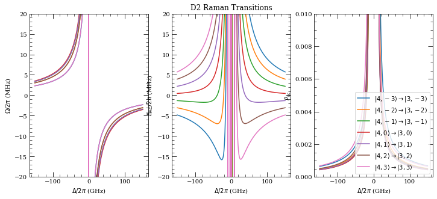

```python
# Test Raman Transition Calculation
#==================================

#Laser Parameters
Pa=0.1e-3;wa=5e-6;qa=-1;
Pb=0.1e-3;wb=5e-6;qb=-1;

#Detuning Array
Delta0=-50e9*2*np.pi
Delta=np.linspace(-150,150,10000)*1e9*2*np.pi

#D1 Line
ne=6;le=1;je=0.5;f1=4; mf1=0; f0=3; mf0=0;
[OmR,AC,Psc]=cs.groundstateRamanTransition(Pa,wa,qa,Pb,wb,qb,Delta0,f0,mf0,f1,mf1,ne,le,je)
print('\nRaman Transitions |%d,%d> to |%d,%d> via %dP_%d/2' % (f1,mf1,f0,mf0,ne,je*2))
print('\tParameters:\tDelta/2pi = %2.f GHz, Pa = %1.2f mW, wa = %2.1f um, Pa = %1.2f mW, wa = %2.1f um' \
      % (Delta0/2.0/np.pi*1e-9,Pa*1e3,wa*1e6,Pb*1e3,wb*1e6))
print('\tResults:\tOmR/2pi = %2.5f MHz, AC/2pi = %2.5f MHz, Psc = %f' % (OmR/2.0/np.pi*1e-6,AC/2.0/np.pi*1e-6,Psc))

#D2 Line
ne=6;le=1;je=1.5;
[OmR,AC,Psc]=cs.groundstateRamanTransition(Pa,wa,qa,Pb,wb,qb,Delta0,f0,mf0,f1,mf1,ne,le,je)
print('\nRaman Transitions |%d,%d> to |%d,%d> via %dP_%d/2' % (f1,mf1,f0,mf0,ne,je*2))
print('\tParameters:\tDelta/2pi = %2.f GHz, Pa = %1.2f mW, wa = %2.1f um, Pa = %1.2f mW, wa = %2.1f um' \
      % (Delta0/2.0/np.pi*1e-9,Pa*1e3,wa*1e6,Pb*1e3,wb*1e6))
print('\tResults:\tOmR/2pi = %2.5f MHz, AC/2pi = %2.5f MHz, Psc = %f' % (OmR/2.0/np.pi*1e-6,AC/2.0/np.pi*1e-6,Psc))

#7P1/2
ne=7;le=1;je=0.5;Pa=10e-3;Pb=10e-3;
[OmR,AC,Psc]=cs.groundstateRamanTransition(Pa,wa,qa,Pb,wb,qb,Delta0,f0,mf0,f1,mf1,ne,le,je)
print('\nRaman Transitions |%d,%d> to |%d,%d> via %dP_%d/2' % (f1,mf1,f0,mf0,ne,je*2))
print('\tParameters:\tDelta/2pi = %2.f GHz, Pa = %1.2f mW, wa = %2.1f um, Pa = %1.2f mW, wa = %2.1f um' \
      % (Delta0/2.0/np.pi*1e-9,Pa*1e3,wa*1e6,Pb*1e3,wb*1e6))
print('\tResults:\tOmR/2pi = %2.5f MHz, AC/2pi = %2.5f MHz, Psc = %f' % (OmR/2.0/np.pi*1e-6,AC/2.0/np.pi*1e-6,Psc))

#7P3/2
ne=7;le=1;je=1.5;Pa=10e-3;Pb=10e-3;
[OmR,AC,Psc]=cs.groundstateRamanTransition(Pa,wa,qa,Pb,wb,qb,Delta0,f0,mf0,f1,mf1,ne,le,je)
print('\nRaman Transitions |%d,%d> to |%d,%d> via %dP_%d/2' % (f1,mf1,f0,mf0,ne,je*2))
print('\tParameters:\tDelta/2pi = %2.f GHz, Pa = %1.2f mW, wa = %2.1f um, Pa = %1.2f mW, wa = %2.1f um' \
      % (Delta0/2.0/np.pi*1e-9,Pa*1e3,wa*1e6,Pb*1e3,wb*1e6))
print('\tResults:\tOmR/2pi = %2.5f MHz, AC/2pi = %2.5f MHz, Psc = %f' % (OmR/2.0/np.pi*1e-6,AC/2.0/np.pi*1e-6,Psc))

#Prepare Output Figure
[f,ax]=plt.subplots(1,3,figsize=(12, 5))
ax[0].set_xlabel(r'$\Delta/2\pi$ (GHz)')
ax[0].set_ylabel(r'$\Omega/2\pi$ (MHz)')
ax[0].set_ylim([-20,20])
ax[1].set_xlabel(r'$\Delta/2\pi$ (GHz)')
ax[1].set_ylabel(r'$\Delta_\mathrm{AC}/2\pi$ (MHz)')
ax[1].set_ylim([-20,20])
ax[2].set_xlabel(r'$\Delta/2\pi$ (GHz)')
ax[2].set_ylabel(r'$P_\mathrm{sc}$')
ax[2].set_ylim([0,0.01])

#Reset to D2 Line
ne=6;le=1;je=1.5;f1=4; mf1=0; f0=3; mf0=0;
Pa=0.1e-3;wa=5e-6;qa=-1;
Pb=0.1e-3;wb=5e-6;qb=-1;

for mf in range(-3,4):
    [OmR,AC,Psc]=cs.groundstateRamanTransition(Pa,wa,qa,Pb,wb,qb,Delta,f1,mf,f0,mf+qa-qb,ne,le,je)
    ax[0].plot(Delta/(2e9*np.pi),OmR/(2e6*np.pi))
    ax[1].plot(Delta/(2e9*np.pi),AC/(2e6*np.pi))
    ax[2].plot(Delta/(2e9*np.pi),Psc,label=format("$\\vert%d,%d\\rangle\\rightarrow\\vert%d,%d\\rangle$" % (f1,mf,f0,mf)))
ax[2].legend(loc=4)
ax[1].set_title('D2 Raman Transitions')
plt.show()
```

## Two-photon Rydberg excitation

[figure not shown]

We consider here the case of two-photon ground-state Raman transitions from $\vert g \rangle = \vert f_g,m_{f_g}\rangle$ to $\vert r \rangle = \vert n_r,l_r,j_r,m_{j_r}\rangle$ via an intermediate excited state $\vert e\rangle = \vert f_e,m_{f_e}\rangle$. In the rotating wave approximation, the Hamiltonian can be written as

\begin{equation} \mathcal{H} = \hbar\begin{pmatrix} 0 & \Omega_p/2 & 0 \\\Omega_p/2 & -\Delta_p & \Omega_c/2 \\ 0 & \Omega_c/2 & -\delta\end{pmatrix}, \end{equation}

where $\Omega_p$ is the Rabi frequency from $\vert 0\rangle\rightarrow\vert e\rangle$ due to the probe laser and $\Omega_c$ is the Rabi frequency from $\vert e\rangle\rightarrow\vert r\rangle$ due to the coupling laser, $\delta=(\Delta_p+\Delta_c)$ is the two-photon detuning.

In the limit $\Delta_p \gg \Omega_p,\Omega_c,\Gamma_e$ the intermediate excited state can be adiabatically elliminiated leading to an effective two-photon Rabi frequency $\Omega_R = \Omega_p\Omega_c/2\Delta$ and an effective detuning $\delta_\mathrm{eff}=\delta+\Delta_\mathrm{AC}$ where $\Delta_\mathrm{AC}$ is the differential Stark shift given by

\begin{equation} \Delta_\mathrm{AC} = \frac{\vert\Omega_p\vert^2}{4\Delta_p} - \frac{\vert\Omega_c\vert^2}{4\Delta_c}. \end{equation}

On the two-photon transition ($\delta_\mathrm{eff}=0$), the probability of spontanteous emission during a $\pi$-pulse can be evaluated from $P_\mathrm{sc}=\Gamma_e\rho_e\tau_\pi$, where $\tau_\pi=\pi/\Omega_R$ is the $\pi$-pulse duration and $\rho_e$ is the excited state population given by

\begin{equation} \rho_e = \frac{1}{2}\left(\frac{\vert\Omega_p\vert^2}{2\Delta_p^2}+\frac{\vert\Omega_c\vert^2}{2\Delta_c^2}\right). \end{equation}

For a multi-level atom, the terms describing Raman transition, diffrential AC Stark shift and scattering probability must be calculated by summing over the $\vert f_e,m_{f_e}\rangle$ states of the intermediate excited state. Additionally, for transitions between hyperfine ground states separated by frequency $\omega_{01}$ we must also account for the off-resonant AC Stark shift and scattering terms arising from laser A acting on $\vert 1 \rangle$ with detuning $\Delta'=\Delta+\omega_{01}$ and laser B acting on $\vert 0 \rangle$ with detuning $\Delta'=\Delta-\omega_{01}$.

\begin{align} \Omega_R&=\displaystyle\sum_{f_e,m_{f_e}}\frac{\Omega_p^{g\rightarrow f_e}\Omega_c^{f_e\rightarrow r}}{2(\Delta-\Delta_{f_e})}\\ \Delta_{\mathrm{AC}_g} &= \displaystyle\sum_{f_e,m_{f_e}}\frac{\vert\Omega_p^{g\rightarrow f_e}\vert^2}{4(\Delta-\Delta_{f_e})}\\ \Delta_{\mathrm{AC}_r} &= \displaystyle\sum_{f_e,m_{f_e}}\frac{\vert\Omega_c^{f_e\rightarrow r}\vert^2}{4(\Delta-\Delta_{f_e})}\\ P_\mathrm{sc} &= \frac{\Gamma_et_\pi}{2}\displaystyle\sum_{f_e,m_{f_e}}\left[\frac{\vert\Omega_p^{g\rightarrow f_e}\vert^2}{2(\Delta-\Delta_{f_e})^2}+\frac{\vert\Omega_c^{f_e\rightarrow r}\vert^2}{2(\Delta-\Delta_{f_e})^2}\right] \end{align}

### ARC Implementation

- [OmegaR,ACg,ACr,Psc] = twoPhotonRydbergExcitation(Pp,wp,qp,Pc,wc,qc,Delta,fg,mfg,ne,le,je,nr,lr,jr,mjr)

  Returns two-photon Rabi frequency $\Omega_R$, ground-state AC Starkshift $\Delta_\mathrm{AC_g}$, Rydberg-state AC Starkshift $\Delta_\mathrm{AC_r}$ and scattering probability $P_\mathrm{sc}$ for transition from $\vert f_g,m_{f_g}\rangle\rightarrow n_rL_{j_r}\vert j_r,m_{j_r}\rangle$ via intermediate excited state with quantum numbers $n_e,\ell_e,j_e$ with detuning $\Delta$ from excited state centre of mass driven by probe/coupling lasers with power $P$, waist $w$ and polarisation $q$ driving transitions from $\vert g\rangle,\vert r\rangle$ respectively.

```
Rydberg Excitation 6S1/2 |4,0> to 80S |1/2,-1/2> via 6P_3/2

	Parameters:	Delta/2pi = 1.10 GHz, Pp = 0.50 uW, wp = 3.0 um, qp=1, Pc = 200.00 mW, wc = 5.0 um, qc=-1

	Results:	OmR/2pi = -3.31688 MHz
			ACg/2pi = 7.64903 MHz
			ACr/2pi = 7.54096 MHz
			Delta_AC/2pi = 0.10807 MHz
			Psc = 0.077362
```

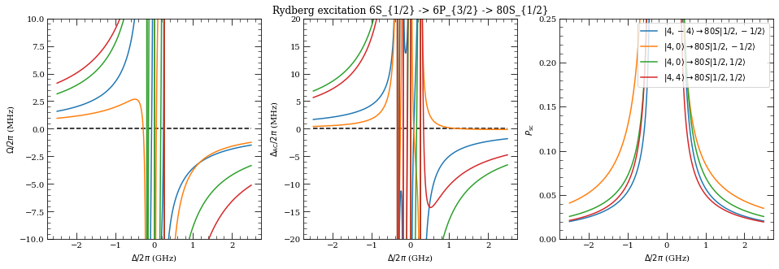

```python
#Rydberg Excitation vs 6P3/2
Pp=500e-9;wp=3e-6;qp=1;
Pc=200e-3;wc=5e-6;qc=-1;
#Ground State
fg=4;mfg=0;
#Excited state (6P3/2)
ne=6;le=1;je=1.5;
#Rydberg state (82S1/2)
nr=80;lr=0;jr=0.5;mjr=-0.5;

SPD='SPD'

#Detuning Array
Delta0=1.1e9*2*np.pi
Delta=np.linspace(-2.5,2.5,1001)*1e9*2*np.pi

[OmR,ACg,ACr,Psc]=cs.twoPhotonRydbergExcitation(Pp,wp,qp,Pc,wc,qc,Delta0,fg,mfg,ne,le,je,nr,lr,jr,mjr)
print('\nRydberg Excitation 6S1/2 |%d,%d> to %d%c |%d/2,%d/2> via %dP_%d/2' % (fg,mfg,nr,SPD[lr],2*jr,2*mjr,ne,je*2))
print('\n\tParameters:\tDelta/2pi = %2.2f GHz, Pp = %1.2f uW, wp = %2.1f um, qp=%d, Pc = %1.2f mW, wc = %2.1f um, qc=%d' \
      % (Delta0/2.0/np.pi*1e-9,Pp*1e6,wp*1e6,qp,Pc*1e3,wc*1e6,qc))
print('\n\tResults:\tOmR/2pi = %2.5f MHz\n\t\t\tACg/2pi = %2.5f MHz\n\t\t\tACr/2pi = %2.5f MHz\n\t\t\tDelta_AC/2pi = %2.5f MHz\n\t\t\tPsc = %f' \
      % (OmR/2.0/np.pi*1e-6,ACg/2.0/np.pi*1e-6,ACr/2.0/np.pi*1e-6,(ACg-ACr)/2.0/np.pi*1e-6,Psc))

#Prepare Output Figure
[f,ax]=plt.subplots(1,3,figsize=(16, 5))
ax[0].set_xlabel(r'$\Delta/2\pi$ (GHz)')
ax[0].set_ylabel(r'$\Omega/2\pi$ (MHz)')
ax[0].set_ylim([-10,10])
ax[1].set_xlabel(r'$\Delta/2\pi$ (GHz)')
ax[1].set_ylabel(r'$\Delta_\mathrm{AC}/2\pi$ (MHz)')
ax[1].set_ylim([-20,20])
ax[2].set_xlabel(r'$\Delta/2\pi$ (GHz)')
ax[2].set_ylabel(r'$P_\mathrm{sc}$')
ax[2].set_ylim([0,0.25])
ax[0].plot(Delta/(2e9*np.pi),0*Delta,'k--')
ax[1].plot(Delta/(2e9*np.pi),0*Delta,'k--')

mj=-jr-1
for m in range(int(2*jr+1)):
    mj+=1
    for mfg in [-fg,0,fg]:
        [OmR,ACg,ACr,Psc]=cs.twoPhotonRydbergExcitation(Pp,wp,qp,Pc,wc,qc,Delta,fg,mfg,ne,le,je,nr,lr,jr,mj)
        if(np.sum(np.abs(OmR))>0.1):
            ax[0].plot(Delta/(2e9*np.pi),OmR/(2e6*np.pi))
            ax[1].plot(Delta/(2e9*np.pi),(ACg-ACr)/(2e6*np.pi))
            ax[2].plot(Delta/(2e9*np.pi),Psc,label=format("$\\vert%d,%d\\rangle\\rightarrow%d%c\\vert%1.0f/2,%1.0f/2\\rangle$" \
                                                      % (fg,mfg,nr,SPD[lr],2*jr,2*mj)))
ax[2].legend(loc=1)
ax[1].set_title('Rydberg excitation 6S_{1/2} -> %dP_{%1.f/2} -> %d%c_{%1.0f/2}'%(ne,2*je,nr,SPD[lr],2*jr))


plt.show()
```

```
Rydberg Excitation 6S1/2 |4,0> to 80S |1/2,-1/2> via 7P_1/2

	Parameters:	Delta/2pi = 1.00 GHz, Pp = 1535.00 uW, wp = 5.0 um, qp=1, Pc = 20.00 mW, wc = 3.0 um, qc=-1

	Results:	OmR/2pi = 11.70666 MHz
			ACg/2pi = 16.15630 MHz
			ACr/2pi = 16.59130 MHz
			Delta_AC/2pi = -0.43500 MHz
			Psc = 0.009768
```

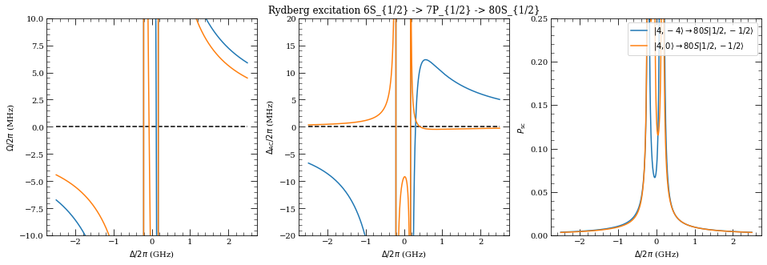

```python
#Rydberg Excitation vs 7P1/2
Pp=1.535e-3;wp=5e-6;qp=1;
Pc=20e-3;wc=3e-6;qc=-1;
#Ground State
fg=4;mfg=0;
#Excited state (7P1/2)
ne=7;le=1;je=0.5;
#Rydberg state (82S1/2)
nr=80;lr=0;jr=0.5;mjr=-0.5;

#Detuning Array
Delta0=1e9*2*np.pi
Delta=np.linspace(-2.5,2.5,1001)*1e9*2*np.pi

[OmR,ACg,ACr,Psc]=cs.twoPhotonRydbergExcitation(Pp,wp,qp,Pc,wc,qc,Delta0,fg,mfg,ne,le,je,nr,lr,jr,mjr)
print('\nRydberg Excitation 6S1/2 |%d,%d> to %d%c |%d/2,%d/2> via %dP_%d/2' % (fg,mfg,nr,SPD[lr],2*jr,2*mjr,ne,je*2))
print('\n\tParameters:\tDelta/2pi = %2.2f GHz, Pp = %1.2f uW, wp = %2.1f um, qp=%d, Pc = %1.2f mW, wc = %2.1f um, qc=%d' \
      % (Delta0/2.0/np.pi*1e-9,Pp*1e6,wp*1e6,qp,Pc*1e3,wc*1e6,qc))
print('\n\tResults:\tOmR/2pi = %2.5f MHz\n\t\t\tACg/2pi = %2.5f MHz\n\t\t\tACr/2pi = %2.5f MHz\n\t\t\tDelta_AC/2pi = %2.5f MHz\n\t\t\tPsc = %f' \
      % (OmR/2.0/np.pi*1e-6,ACg/2.0/np.pi*1e-6,ACr/2.0/np.pi*1e-6,(ACg-ACr)/2.0/np.pi*1e-6,Psc))

#Prepare Output Figure
[f,ax]=plt.subplots(1,3,figsize=(16, 5))
ax[0].set_xlabel(r'$\Delta/2\pi$ (GHz)')
ax[0].set_ylabel(r'$\Omega/2\pi$ (MHz)')
ax[0].set_ylim([-10,10])
ax[1].set_xlabel(r'$\Delta/2\pi$ (GHz)')
ax[1].set_ylabel(r'$\Delta_\mathrm{AC}/2\pi$ (MHz)')
ax[1].set_ylim([-20,20])
ax[2].set_xlabel(r'$\Delta/2\pi$ (GHz)')
ax[2].set_ylabel(r'$P_\mathrm{sc}$')
ax[2].set_ylim([0,0.25])
ax[0].plot(Delta/(2e9*np.pi),0*Delta,'k--')
ax[1].plot(Delta/(2e9*np.pi),0*Delta,'k--')

SPD='SPD'

mj=-jr-1
for m in range(int(2*jr+1)):
    mj+=1
    for mfg in [-fg,0,fg]:
        [OmR,ACg,ACr,Psc]=cs.twoPhotonRydbergExcitation(Pp,wp,qp,Pc,wc,qc,Delta,fg,mfg,ne,le,je,nr,lr,jr,mj)
        if(np.sum(np.abs(OmR))>0.1):
            ax[0].plot(Delta/(2e9*np.pi),OmR/(2e6*np.pi))
            ax[1].plot(Delta/(2e9*np.pi),(ACg-ACr)/(2e6*np.pi))
            ax[2].plot(Delta/(2e9*np.pi),Psc,label=format("$\\vert%d,%d\\rangle\\rightarrow%d%c\\vert%1.0f/2,%1.0f/2\\rangle$" \
                                                      % (fg,mfg,nr,SPD[lr],2*jr,2*mj)))
ax[2].legend(loc=1)
ax[1].set_title('Rydberg excitation 6S_{1/2} -> %dP_{%1.f/2} -> %d%c_{%1.0f/2}'%(ne,2*je,nr,SPD[lr],2*jr))


plt.show()
```

## Magnetic Functions

- getLandegj(l,j,s=0.5)

  Returns fine-structure Landé g-factor $g_J$

\begin{equation} g_J\simeq 1+\frac{j(j+1)+s(s+1)-l(l+1)}{2j(j+1)} \end{equation}

- getLandegjExact(l,j,s=0.5)

  Returns fine-structure Landé g-factor $g_J$ using precise $g_L,$ $g_S$ values

\begin{equation} g_J=g_L\frac{j(j+1)-s(s+1)+l(l+1)}{2j(j+1)}+g_S\frac{j(j+1)+s(s+1)-l(l+1)}{2j(j+1)} \end{equation}

- getLandegf(l,j,f,s=0.5)

  Returns hyperfine-structure Landé g-factor $g_F$

\begin{equation} g_F\simeq g_J\frac{f(f+1)-I(I+1)+j(j+1)}{2f(f+1)} \end{equation}

- getLandegfExact(l,j,f,s=0.5)

  Returns hyperfine-structure Landé g-factor $g_F$ using precise $g_L,$ $g_S$, $g_I$ values

\begin{equation} g_F=g_J\frac{f(f+1)-I(I+1)+j(j+1)}{2f(f+1)}+g_I\frac{f(f+1)+I(I+1)-j(j+1)}{2f(f+1)} \end{equation}

- Ez = breitRabi(l,j,B,Ahfs,Bhfs)

  Return exact Zeman energy levels for the l,j manifold via diagonalisation of $\mathcal{H}=\mathcal{H}_\mathrm{hfs}+\mathcal{H}_\mathrm{Z}$ where $\mathcal{H}_\mathrm{hfs}$ is the Hamiltonian for the hyperfine interaction given by \begin{equation} \mathcal{H}_\mathrm{hfs}=A_\mathrm{hfs}I\cdot J + B_\mathrm{hfs}\frac{3(I\cdot J)^2+3/2 I\cdot J -I^2J^2}{2I(2I+1)2J(2J+1)}, \end{equation} and $\mathcal{H}_Z$ is the Hamiltonian for the Zeeman interaction given by \begin{equation} \mathcal{H}_Z=\frac{\mu_B}{\hbar}(g_J J_z+g_I I_z)B_z \end{equation}

For the $j=1/2$ ground-state, this can be compared against the breitRabi formula [1]

\begin{equation} E_{\vert j=1/2,m_j,I,m_I\rangle} = -\frac{A_\mathrm{hfs}(I+1/2)}{2(2I+1)}+g_I\mu_B m B_z \pm \frac{A_\mathrm{hfs}(I+1/2)}{2}\left(1+\frac{4mx}{2I+1}+x^2\right)^{1/2}, \end{equation}

where $m=m_I\pm m_j$ and \begin{equation} x=\frac{g_j-g_I)\mu_B B_z}{A_\mathrm{hfs}(I+1/2)}. \end{equation}

```
Cs 6S1/2 gJ = 2.00, F=3 gF = 0.25, F=4 gF = 0.25,
Cs 6S1/2 gJ = 2.002319, F=3 gF = 0.249941, F=4 gF = 0.249941,
```

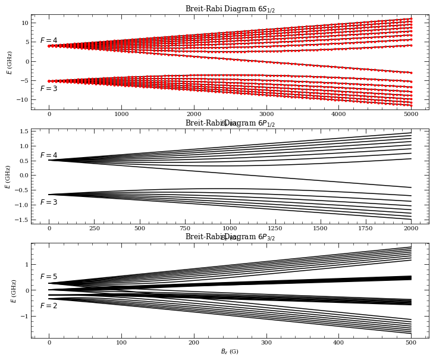

```python
#Lande g-factors
gj = cs.getLandegj(0,0.5)
gf3 = cs.getLandegf(0,0.5,4)
gf4 = cs.getLandegf(0,0.5,4)
print("Cs 6S1/2 gJ = %2.2f, F=3 gF = %2.2f, F=4 gF = %2.2f,"%(gj,gf3,gf4))
gj = cs.getLandegjExact(0,0.5)
gf3 = cs.getLandegfExact(0,0.5,4)
gf4 = cs.getLandegfExact(0,0.5,4)
print("Cs 6S1/2 gJ = %f, F=3 gF = %f, F=4 gF = %f,"%(gj,gf3,gf4))

#Zeeman Interaction 6S1/2
#========================
#Define State of Interest
lg=0;jg=1/2;

#B-Field (G)
B=np.linspace(0,5000,101)*1e-4
#Exact-Diagonalisation (Breit-Rabi)
en,f,mf=cs.breitRabi(6,lg,jg,B)

[f,ax]=plt.subplots(3,1,figsize=(12, 10))
ax[0].plot(B*1e4,en*1e-9,'k')
ax[0].set_xlabel(r'$B_z$ (G)')
ax[0].set_ylabel(r'$E$ (GHz)')
ax[0].set_title(r'Breit-Rabi Diagram $6S_{1/2}$')

#Plot Breit-Rabi Formula
#=======================
#   Steck Eq(25)
#                         dEhfs                dEhfs      4mx
#   E(j=1/2,mj;I,mI) = - ------- + gI*uB*m*B ± ----- (1+ ----- + x^2)^{1/2}
#                        2(2I+1)                 2        2I+1
#
#   where m=mI±mj to match sign above and x=(gj-gI)uB*B/dEhfs
uB = physical_constants["Bohr magneton in Hz/T"][0]
[Ahfs,Bhfs]=cs.getHFSCoefficients(6,0,0.5)
qhfs = Ahfs*(cs.I+jg)
gj=cs.getLandegjExact(lg,jg)
#Rescale to x
x=(gj-cs.gI)*uB*B/qhfs;

Ebr = np.zeros(np.shape(en))

ctr=-1
for mI in np.arange(-cs.I,1+cs.I):
    for mj in np.arange(-jg,1+jg):
        m=mI+mj
        ctr+=1
        if(abs(m)==(cs.I+jg)):
            Ebr[:,ctr]=qhfs*cs.I/(2*cs.I+1)+np.sign(mj)*1/2*(gj+2*cs.gI)*uB*B
        else:
            Ebr[:,ctr]=-qhfs/(2*(2*cs.I+1))+cs.gI*uB*m*B+np.sign(mj)*qhfs/2*np.sqrt(1+4*m*x/(2*cs.I+1)+x**2)

ax[0].plot(B*1e4,Ebr*1e-9,'r.');

ax[0].text(0,min(en[0,:])*1.5e-9,r"$F=3$",horizontalalignment='center',fontsize=12)
ax[0].text(0,max(en[0,:])*1.2e-9,r"$F=4$",horizontalalignment='center',fontsize=12)


#6P1/2

#Exact-Diagonalisation (Breit-Rabi)
B=np.linspace(0,2000,101)*1e-4
en,f,mf=cs.breitRabi(6,1,0.5,B)
ax[1].plot(B*1e4,en*1e-9,'k')
ax[1].set_xlabel(r'$B_z$ (G)')
ax[1].set_ylabel(r'$E$ (GHz)')
ax[1].set_title(r'Breit-Rabi Diagram $6P_{1/2}$')
ax[1].text(0,min(en[0,:])*1.5e-9,r"$F=3$",horizontalalignment='center',fontsize=12)
ax[1].text(0,max(en[0,:])*1.2e-9,r"$F=4$",horizontalalignment='center',fontsize=12)

#Exact-Diagonalisation (Breit-Rabi)
B=np.linspace(0,500,101)*1e-4
en,f,mf=cs.breitRabi(6,1,1.5,B)
ax[2].plot(B*1e4,en*1e-9,'k')
ax[2].set_xlabel(r'$B_z$ (G)')
ax[2].set_ylabel(r'$E$ (GHz)')
ax[2].set_title(r'Breit-Rabi Diagram $6P_{3/2}$')
ax[2].text(0,min(en[0,:])*2e-9,r"$F=2$",horizontalalignment='center',fontsize=12)
ax[2].text(0,max(en[0,:])*1.7e-9,r"$F=5$",horizontalalignment='center',fontsize=12)

plt.show()
```